# COSC-523: Project 03 Part 2: Implementing U-Net for retinal vessel prediction

**Daniel Carter**

[Notebook Link](https://colab.research.google.com/drive/1Q-6PcppBjhqQsm47bRy93lt4qFrwI4RX#scrollTo=g8FRb4_ZbdZ6)

## Getting Started

Follow the instructions below to copy this notebook and to perform some initial setup.

1. Copy this notebook by selecting `File > Save a copy in Drive`.
2. A new window should open for the copied notebook. Move the new notebook to your course folder in Google Drive by selecting `File > Move` and then selecting the desired folder.
3. Update the name of the notebook by removing "Copy of" and replacing "Username" with your actual username.
4. Update the first cell in the notebook by specifying your course number (423 or 523) and by replacing "**Student Name**" with your actual name.
5. Do not edit the line that says `PLACEHOLDER_FOR_NOTEBOOK_LINK`. This will be used by the [Notebook Renderer](https://colab.research.google.com/drive/1CJTipys46ldZxJFwnt7XbdjQUfkmoXeU?usp=sharing) tool to insert a link to your Colab notebook.
6. Enable link sharing for your notebook.

# Description :

First, make sure you are connected to TPU. In this project we will implement a U-net model from scratch and use it to predict retinal vessels. You can check out the output image shared on Canvas to see what the goal is.  
Most of the code for this project is given to you and some tasks have errors.  
The cells below include the code for this application and instructions are present to guide you if there is an incomplete section or a section with errors.

# Task 1: Error detection: 15 points

The code below starts the application by importing libraries and then loading the images and masks (there are only 80 in total, not enough). Since there are not enough images it creates augmented versions for both the images and the masks. This part of code may run correctly at first, but when you compile the model or train the model you might see an error. I would recommend that if you can't find the error quickly, proceed to the other parts (the ones that are incomplete) and then run this section, fixing it based off of the error message.

- Wherever you do make a fix, please mention the change as a comment in capital letters

```python
import cv2
import numpy as np
import os
from google.colab import files
from google.colab import drive
from keras.callbacks import EarlyStopping, ModelCheckpoint
from keras.callbacks import LearningRateScheduler
from sklearn.model_selection import train_test_split
import math
from tensorflow.keras.metrics import MeanIoU
from keras.optimizers import Adam
from tensorflow.keras.losses import BinaryCrossentropy
from tensorflow.keras.preprocessing.image import ImageDataGenerator, img_to_array, load_img
import numpy as np
import random
from PIL import Image

# Mount Google Drive to access files (if using Drive)
drive.mount('/content/drive')

# Alternatively, upload files using Colab's upload feature
#uploaded = files.upload()  # Upload images and masks manually

def load_and_preprocess_images(image_dir, mask_dir, target_size=(256, 256), num_augmented_images=800):
    # Define the same seed to ensure same transformation on image and mask
    seed = 42

    # Image data generator
    image_datagen = ImageDataGenerator(
        rotation_range=20,
        width_shift_range=0.1,
        height_shift_range=0.1,
        shear_range=0.1,
        zoom_range=0.1,
        horizontal_flip=True,
        fill_mode='nearest'
    )

    # Mask data generator — no interpolation to preserve binary values
    mask_datagen = ImageDataGenerator(
        rotation_range=20,
        width_shift_range=0.1,
        height_shift_range=0.1,
        shear_range=0.1,
        zoom_range=0.1,
        horizontal_flip=True,
        fill_mode='nearest'
    )

    image_filenames = [f for f in os.listdir(image_dir)
                       if f.lower().endswith(('.png', '.jpg', '.jpeg')) and
                          os.path.exists(os.path.join(mask_dir, f))]

    print(f"Found {len(image_filenames)} matched image-mask pairs.")

    augmented_images = []
    augmented_masks = []

    while len(augmented_images) < num_augmented_images:
        filename = random.choice(image_filenames)

        # Load and resize image
        img_path = os.path.join(image_dir, filename)
        mask_path = os.path.join(mask_dir, filename)

        img = load_img(img_path, target_size=target_size)
        mask = load_img(mask_path, target_size=target_size, color_mode="grayscale")

        x_img = img_to_array(img)
        x_mask = img_to_array(mask)

        # Expand dimensions to make shape (1, h, w, c)
        x_img = np.expand_dims(x_img, axis=0)
        x_mask = np.expand_dims(x_mask, axis=0)

        # Create generators
        img_gen = image_datagen.flow(x_img, batch_size=1, seed=seed)
        mask_gen = mask_datagen.flow(x_mask, batch_size=1, seed=seed)

        # Generate one pair
        aug_img = next(img_gen)[0].astype(np.uint8)
        aug_mask = next(mask_gen)[0]

        # Ensure binary mask (e.g., values exactly 0 or 255, or 0 and 1)
        aug_mask = (aug_mask > 127).astype(np.uint8) * 255

        augmented_images.append(aug_img)
        augmented_masks.append(aug_mask)

    augmented_images = np.array(augmented_images, dtype=np.uint8)
    augmented_masks = np.array(augmented_masks, dtype=np.uint8)

    print(f"Generated {len(augmented_images)} image-mask pairs.")

    return augmented_images, augmented_masks

# The paths below should work for your images and masks if you downloaded and uploaded the folders to your drive
image_dir = '/content/drive/MyDrive/trainimagesunet-20250615T224930Z-1-001/trainimagesunet'
mask_dir = '/content/drive/MyDrive/trainmasksunet-20250615T225007Z-1-001/trainmasksunet'

# Load and preprocess images and masks
images, masks = load_and_preprocess_images(image_dir, mask_dir)
images = np.array(images) / 255.0
masks = (masks > 127).astype(np.float32)

# Check shape of loaded images and masks
print(images.shape, masks.shape)
```

```
Found 80 matched image-mask pairs.
Generated 800 image-mask pairs.
(800, 256, 256, 3) (800, 256, 256, 1)
```

# Task 2: Incomplete Model: 35 points

This next section has an incomplete model and has no errors. Here are the instructions for creating the model:

- The U-Net paper on Canvas shows the structure of the UNet on page 3, mimic this structure and create the layers, but make sure that right from the beginning, the amount of filters in this code is twice of what the U-Net model in the paper has

```python
import tensorflow as tf
from tensorflow.keras.layers import Conv2D, MaxPooling2D, UpSampling2D, Concatenate, Input, Dropout
from tensorflow.keras.models import Model

def custom_unet(input_shape=(256, 256, 3)): # TO MATCH WHAT THE GIVEN PROCESSING FUNCTION CONVERTS THE IMGS TO, CHANGE FROM 128,128,1 to 256,256,3
    inputs = Input(input_shape)

    # Encoder (build from scratch)
    e1 = Conv2D(64, 3, activation='relu', padding='same')(inputs)
    e1 = Conv2D(64, 3, activation='relu', padding='same')(e1)
    e1 = Dropout(0.1)(e1)
    p1 = MaxPooling2D(pool_size=(2, 2))(e1)

    # e2
    e2 = Conv2D(128, 3, activation='relu', padding='same')(p1)
    e2 = Conv2D(128, 3, activation='relu', padding='same')(e2)
    e2 = Dropout(0.1)(e2)
    p2 = MaxPooling2D(pool_size=(2, 2))(e2)

    # e3
    e3 = Conv2D(256, 3, activation='relu', padding='same')(p2)
    e3 = Conv2D(256, 3, activation='relu', padding='same')(e3)
    e3 = Dropout(0.1)(e3)
    p3 = MaxPooling2D(pool_size=(2, 2))(e3)

    # e4
    e4 = Conv2D(512, 3, activation='relu', padding='same')(p3)
    e4 = Conv2D(512, 3, activation='relu', padding='same')(e4)
    e4 = Dropout(0.1)(e4)
    p4 = MaxPooling2D(pool_size=(2, 2))(e4)

    # e5
    e5 = Conv2D(1024, 3, activation='relu', padding='same')(p4)
    e5 = Conv2D(1024, 3, activation='relu', padding='same')(e5)
    e5 = Dropout(0.1)(e5)
    # no maxpooling


    # Decoder (upsampling and concatenation with skip connections)
    d1 = UpSampling2D()(e5)
    d1 = Concatenate()([d1, e4])
    d1 = Conv2D(512, 3, activation='relu', padding='same')(d1)
    d1 = Conv2D(512, 3, activation='relu', padding='same')(d1)
    d1 = Dropout(0.1)(d1)

    # d2
    d2 = UpSampling2D()(d1)
    d2 = Concatenate()([d2, e3])
    d2 = Conv2D(256, 3, activation='relu', padding='same')(d2)
    d2 = Conv2D(256, 3, activation='relu', padding='same')(d2)
    d2 = Dropout(0.1)(d2)

    # d3
    d3 = UpSampling2D()(d2)
    d3 = Concatenate()([d3, e2])
    d3 = Conv2D(128, 3, activation='relu', padding='same')(d3)
    d3 = Conv2D(128, 3, activation='relu', padding='same')(d3)
    d3 = Dropout(0.1)(d3)

    # d4
    d4 = UpSampling2D()(d3)
    d4 = Concatenate()([d4, e1])
    d4 = Conv2D(64, 3, activation='relu', padding='same')(d4)
    d4 = Conv2D(64, 3, activation='relu', padding='same')(d4)
    d4 = Dropout(0.1)(d4)

    # Final output layer
    output = Conv2D(1, 1, activation='sigmoid')(d4)

    # Build and return model
    model = Model(inputs, output)
    return model

model = custom_unet()

optimizer = Adam(learning_rate=0.01)
model.compile(optimizer= optimizer, loss=BinaryCrossentropy(), metrics=[MeanIoU(num_classes=2)])
model.summary()
```

```
Model: "functional"
```

```
┏━━━━━━━━━━━━━━━━━━━━━┳━━━━━━━━━━━━━━━━━━━┳━━━━━━━━━━━━┳━━━━━━━━━━━━━━━━━━━┓
┃ Layer (type)        ┃ Output Shape      ┃    Param # ┃ Connected to      ┃
┡━━━━━━━━━━━━━━━━━━━━━╇━━━━━━━━━━━━━━━━━━━╇━━━━━━━━━━━━╇━━━━━━━━━━━━━━━━━━━┩
│ input_layer         │ (None, 256, 256,  │          0 │ -                 │
│ (InputLayer)        │ 3)                │            │                   │
├─────────────────────┼───────────────────┼────────────┼───────────────────┤
│ conv2d (Conv2D)     │ (None, 256, 256,  │      1,792 │ input_layer[0][0] │
│                     │ 64)               │            │                   │
├─────────────────────┼───────────────────┼────────────┼───────────────────┤
│ conv2d_1 (Conv2D)   │ (None, 256, 256,  │     36,928 │ conv2d[0][0]      │
│                     │ 64)               │            │                   │
├─────────────────────┼───────────────────┼────────────┼───────────────────┤
│ dropout (Dropout)   │ (None, 256, 256,  │          0 │ conv2d_1[0][0]    │
│                     │ 64)               │            │                   │
├─────────────────────┼───────────────────┼────────────┼───────────────────┤
│ max_pooling2d       │ (None, 128, 128,  │          0 │ dropout[0][0]     │
│ (MaxPooling2D)      │ 64)               │            │                   │
├─────────────────────┼───────────────────┼────────────┼───────────────────┤
│ conv2d_2 (Conv2D)   │ (None, 128, 128,  │     73,856 │ max_pooling2d[0]… │
│                     │ 128)              │            │                   │
├─────────────────────┼───────────────────┼────────────┼───────────────────┤
│ conv2d_3 (Conv2D)   │ (None, 128, 128,  │    147,584 │ conv2d_2[0][0]    │
│                     │ 128)              │            │                   │
├─────────────────────┼───────────────────┼────────────┼───────────────────┤
│ dropout_1 (Dropout) │ (None, 128, 128,  │          0 │ conv2d_3[0][0]    │
│                     │ 128)              │            │                   │
├─────────────────────┼───────────────────┼────────────┼───────────────────┤
│ max_pooling2d_1     │ (None, 64, 64,    │          0 │ dropout_1[0][0]   │
│ (MaxPooling2D)      │ 128)              │            │                   │
├─────────────────────┼───────────────────┼────────────┼───────────────────┤
│ conv2d_4 (Conv2D)   │ (None, 64, 64,    │    295,168 │ max_pooling2d_1[… │
│                     │ 256)              │            │                   │
├─────────────────────┼───────────────────┼────────────┼───────────────────┤
│ conv2d_5 (Conv2D)   │ (None, 64, 64,    │    590,080 │ conv2d_4[0][0]    │
│                     │ 256)              │            │                   │
├─────────────────────┼───────────────────┼────────────┼───────────────────┤
│ dropout_2 (Dropout) │ (None, 64, 64,    │          0 │ conv2d_5[0][0]    │
│                     │ 256)              │            │                   │
├─────────────────────┼───────────────────┼────────────┼───────────────────┤
│ max_pooling2d_2     │ (None, 32, 32,    │          0 │ dropout_2[0][0]   │
```

[output cut: 71 more lines]

```
│ concatenate_3       │ (None, 256, 256,  │          0 │ up_sampling2d_3[… │
│ (Concatenate)       │ 192)              │            │ dropout[0][0]     │
├─────────────────────┼───────────────────┼────────────┼───────────────────┤
│ conv2d_16 (Conv2D)  │ (None, 256, 256,  │    110,656 │ concatenate_3[0]… │
│                     │ 64)               │            │                   │
├─────────────────────┼───────────────────┼────────────┼───────────────────┤
│ conv2d_17 (Conv2D)  │ (None, 256, 256,  │     36,928 │ conv2d_16[0][0]   │
│                     │ 64)               │            │                   │
├─────────────────────┼───────────────────┼────────────┼───────────────────┤
│ dropout_8 (Dropout) │ (None, 256, 256,  │          0 │ conv2d_17[0][0]   │
│                     │ 64)               │            │                   │
├─────────────────────┼───────────────────┼────────────┼───────────────────┤
│ conv2d_18 (Conv2D)  │ (None, 256, 256,  │         65 │ dropout_8[0][0]   │
│                     │ 1)                │            │                   │
└─────────────────────┴───────────────────┴────────────┴───────────────────┘
```

```
 Total params: 31,378,945 (119.70 MB)
```

```
 Trainable params: 31,378,945 (119.70 MB)
```

```
 Non-trainable params: 0 (0.00 B)
```

This next section has no errors, please run it as is. If you have done everything correct;y, the mean IOU at the beginning will start with a value of around 0.45 or something like that

```python
# Fit model

X_train, X_val, y_train, y_val = train_test_split(images, masks, test_size=0.10, random_state=42)

#lrate = LearningRateScheduler(step_decay)
def step_decay(epoch):
    initial_lrate = 0.0001
    drop = 0.1
    #initial_lrate = 0.01
    #drop = 0.01
    epochs_drop = 30
    lrate = initial_lrate * math.pow(drop,
           math.floor((1+epoch)/epochs_drop))
    return lrate

#from keras import backend as K
epochs = 50
lrate = LearningRateScheduler(step_decay)
#callbacks_list=[lr, model_ckpt]
earlystopper = EarlyStopping(monitor = 'val_loss',min_delta=1e-4,patience=10, verbose=1) # you can change the patience value to a little lower.
checkpointer = ModelCheckpoint('Unet.h5', monitor = 'val_loss',verbose=1, save_best_only=True)
callbacks_list = [earlystopper, checkpointer,lrate]
results = model.fit(X_train, y_train, validation_data=(X_val,y_val), batch_size=8, epochs=epochs,
                    callbacks=callbacks_list)
```

```
90/90 ━━━━━━━━━━━━━━━━━━━━ 0s 55ms/step - loss: 0.4112 - mean_io_u: 0.4544
Epoch 1: val_loss improved from inf to 0.27765, saving model to Unet.h5
```

[output not shown]

```
90/90 ━━━━━━━━━━━━━━━━━━━━ 37s 105ms/step - loss: 0.4103 - mean_io_u: 0.4545 - val_loss: 0.2777 - val_mean_io_u: 0.4558 - learning_rate: 1.0000e-04
90/90 ━━━━━━━━━━━━━━━━━━━━ 0s 55ms/step - loss: 0.2745 - mean_io_u: 0.4546
Epoch 2: val_loss improved from 0.27765 to 0.26142, saving model to Unet.h5
```

[output not shown]

```
90/90 ━━━━━━━━━━━━━━━━━━━━ 6s 67ms/step - loss: 0.2744 - mean_io_u: 0.4546 - val_loss: 0.2614 - val_mean_io_u: 0.4558 - learning_rate: 1.0000e-04
90/90 ━━━━━━━━━━━━━━━━━━━━ 0s 55ms/step - loss: 0.2615 - mean_io_u: 0.4548
Epoch 3: val_loss improved from 0.26142 to 0.24297, saving model to Unet.h5
```

[output not shown]

```
90/90 ━━━━━━━━━━━━━━━━━━━━ 6s 67ms/step - loss: 0.2615 - mean_io_u: 0.4548 - val_loss: 0.2430 - val_mean_io_u: 0.4558 - learning_rate: 1.0000e-04
90/90 ━━━━━━━━━━━━━━━━━━━━ 0s 55ms/step - loss: 0.2394 - mean_io_u: 0.4547
Epoch 4: val_loss improved from 0.24297 to 0.18554, saving model to Unet.h5
```

[output not shown]

```
90/90 ━━━━━━━━━━━━━━━━━━━━ 6s 67ms/step - loss: 0.2392 - mean_io_u: 0.4547 - val_loss: 0.1855 - val_mean_io_u: 0.4558 - learning_rate: 1.0000e-04
90/90 ━━━━━━━━━━━━━━━━━━━━ 0s 55ms/step - loss: 0.1798 - mean_io_u: 0.4545
Epoch 5: val_loss improved from 0.18554 to 0.14660, saving model to Unet.h5
```

[output not shown]

```
90/90 ━━━━━━━━━━━━━━━━━━━━ 6s 67ms/step - loss: 0.1797 - mean_io_u: 0.4545 - val_loss: 0.1466 - val_mean_io_u: 0.4558 - learning_rate: 1.0000e-04
90/90 ━━━━━━━━━━━━━━━━━━━━ 0s 55ms/step - loss: 0.1434 - mean_io_u: 0.4550
Epoch 6: val_loss improved from 0.14660 to 0.13210, saving model to Unet.h5
```

[output not shown]

```
90/90 ━━━━━━━━━━━━━━━━━━━━ 6s 67ms/step - loss: 0.1433 - mean_io_u: 0.4550 - val_loss: 0.1321 - val_mean_io_u: 0.4558 - learning_rate: 1.0000e-04
90/90 ━━━━━━━━━━━━━━━━━━━━ 0s 55ms/step - loss: 0.1274 - mean_io_u: 0.4549
Epoch 7: val_loss improved from 0.13210 to 0.11757, saving model to Unet.h5
```

[output not shown]

```
90/90 ━━━━━━━━━━━━━━━━━━━━ 6s 67ms/step - loss: 0.1274 - mean_io_u: 0.4549 - val_loss: 0.1176 - val_mean_io_u: 0.4558 - learning_rate: 1.0000e-04
90/90 ━━━━━━━━━━━━━━━━━━━━ 0s 55ms/step - loss: 0.1178 - mean_io_u: 0.4549
Epoch 8: val_loss improved from 0.11757 to 0.10908, saving model to Unet.h5
```

[output not shown]

```
90/90 ━━━━━━━━━━━━━━━━━━━━ 6s 67ms/step - loss: 0.1178 - mean_io_u: 0.4549 - val_loss: 0.1091 - val_mean_io_u: 0.4558 - learning_rate: 1.0000e-04
90/90 ━━━━━━━━━━━━━━━━━━━━ 0s 55ms/step - loss: 0.1094 - mean_io_u: 0.4551
Epoch 9: val_loss improved from 0.10908 to 0.10527, saving model to Unet.h5
```

[output not shown]

```
90/90 ━━━━━━━━━━━━━━━━━━━━ 6s 68ms/step - loss: 0.1094 - mean_io_u: 0.4551 - val_loss: 0.1053 - val_mean_io_u: 0.4558 - learning_rate: 1.0000e-04
90/90 ━━━━━━━━━━━━━━━━━━━━ 0s 55ms/step - loss: 0.1013 - mean_io_u: 0.4545
Epoch 10: val_loss improved from 0.10527 to 0.09605, saving model to Unet.h5
```

[output not shown]

```
90/90 ━━━━━━━━━━━━━━━━━━━━ 6s 67ms/step - loss: 0.1013 - mean_io_u: 0.4545 - val_loss: 0.0961 - val_mean_io_u: 0.4558 - learning_rate: 1.0000e-04
90/90 ━━━━━━━━━━━━━━━━━━━━ 0s 55ms/step - loss: 0.0949 - mean_io_u: 0.4546
Epoch 11: val_loss improved from 0.09605 to 0.08835, saving model to Unet.h5
```

[output not shown]

```
90/90 ━━━━━━━━━━━━━━━━━━━━ 6s 67ms/step - loss: 0.0948 - mean_io_u: 0.4546 - val_loss: 0.0883 - val_mean_io_u: 0.4558 - learning_rate: 1.0000e-04
90/90 ━━━━━━━━━━━━━━━━━━━━ 0s 55ms/step - loss: 0.0869 - mean_io_u: 0.4551
Epoch 12: val_loss improved from 0.08835 to 0.08299, saving model to Unet.h5
```

[output not shown]

```
90/90 ━━━━━━━━━━━━━━━━━━━━ 6s 67ms/step - loss: 0.0869 - mean_io_u: 0.4551 - val_loss: 0.0830 - val_mean_io_u: 0.4558 - learning_rate: 1.0000e-04
90/90 ━━━━━━━━━━━━━━━━━━━━ 0s 55ms/step - loss: 0.0817 - mean_io_u: 0.4544
Epoch 13: val_loss improved from 0.08299 to 0.07472, saving model to Unet.h5
```

[output not shown]

```
90/90 ━━━━━━━━━━━━━━━━━━━━ 6s 67ms/step - loss: 0.0817 - mean_io_u: 0.4544 - val_loss: 0.0747 - val_mean_io_u: 0.4558 - learning_rate: 1.0000e-04
90/90 ━━━━━━━━━━━━━━━━━━━━ 0s 55ms/step - loss: 0.0745 - mean_io_u: 0.4551
Epoch 14: val_loss improved from 0.07472 to 0.06894, saving model to Unet.h5
```

[output not shown]

```
90/90 ━━━━━━━━━━━━━━━━━━━━ 6s 67ms/step - loss: 0.0745 - mean_io_u: 0.4551 - val_loss: 0.0689 - val_mean_io_u: 0.4558 - learning_rate: 1.0000e-04
90/90 ━━━━━━━━━━━━━━━━━━━━ 0s 55ms/step - loss: 0.0698 - mean_io_u: 0.4549
Epoch 15: val_loss improved from 0.06894 to 0.06568, saving model to Unet.h5
```

[output not shown]

```
90/90 ━━━━━━━━━━━━━━━━━━━━ 6s 67ms/step - loss: 0.0698 - mean_io_u: 0.4549 - val_loss: 0.0657 - val_mean_io_u: 0.4558 - learning_rate: 1.0000e-04
90/90 ━━━━━━━━━━━━━━━━━━━━ 0s 55ms/step - loss: 0.0648 - mean_io_u: 0.4551
Epoch 16: val_loss improved from 0.06568 to 0.06112, saving model to Unet.h5
```

[output not shown]

```
90/90 ━━━━━━━━━━━━━━━━━━━━ 6s 67ms/step - loss: 0.0648 - mean_io_u: 0.4551 - val_loss: 0.0611 - val_mean_io_u: 0.4558 - learning_rate: 1.0000e-04
90/90 ━━━━━━━━━━━━━━━━━━━━ 0s 55ms/step - loss: 0.0637 - mean_io_u: 0.4546
Epoch 17: val_loss improved from 0.06112 to 0.05546, saving model to Unet.h5
```

[output not shown]

```
90/90 ━━━━━━━━━━━━━━━━━━━━ 6s 67ms/step - loss: 0.0636 - mean_io_u: 0.4546 - val_loss: 0.0555 - val_mean_io_u: 0.4558 - learning_rate: 1.0000e-04
90/90 ━━━━━━━━━━━━━━━━━━━━ 0s 55ms/step - loss: 0.0573 - mean_io_u: 0.4554
Epoch 18: val_loss improved from 0.05546 to 0.05157, saving model to Unet.h5
```

[output not shown]

```
90/90 ━━━━━━━━━━━━━━━━━━━━ 6s 67ms/step - loss: 0.0573 - mean_io_u: 0.4553 - val_loss: 0.0516 - val_mean_io_u: 0.4558 - learning_rate: 1.0000e-04
90/90 ━━━━━━━━━━━━━━━━━━━━ 0s 55ms/step - loss: 0.0541 - mean_io_u: 0.4551
Epoch 19: val_loss improved from 0.05157 to 0.04862, saving model to Unet.h5
```

[output not shown]

```
90/90 ━━━━━━━━━━━━━━━━━━━━ 6s 67ms/step - loss: 0.0541 - mean_io_u: 0.4551 - val_loss: 0.0486 - val_mean_io_u: 0.4558 - learning_rate: 1.0000e-04
90/90 ━━━━━━━━━━━━━━━━━━━━ 0s 55ms/step - loss: 0.0514 - mean_io_u: 0.4553
Epoch 20: val_loss improved from 0.04862 to 0.04568, saving model to Unet.h5
```

[output not shown]

```
90/90 ━━━━━━━━━━━━━━━━━━━━ 6s 67ms/step - loss: 0.0514 - mean_io_u: 0.4553 - val_loss: 0.0457 - val_mean_io_u: 0.4558 - learning_rate: 1.0000e-04
90/90 ━━━━━━━━━━━━━━━━━━━━ 0s 55ms/step - loss: 0.0489 - mean_io_u: 0.4548
Epoch 21: val_loss improved from 0.04568 to 0.04382, saving model to Unet.h5
```

[output not shown]

```
90/90 ━━━━━━━━━━━━━━━━━━━━ 6s 67ms/step - loss: 0.0489 - mean_io_u: 0.4548 - val_loss: 0.0438 - val_mean_io_u: 0.4558 - learning_rate: 1.0000e-04
90/90 ━━━━━━━━━━━━━━━━━━━━ 0s 55ms/step - loss: 0.0462 - mean_io_u: 0.4554
Epoch 22: val_loss improved from 0.04382 to 0.04078, saving model to Unet.h5
```

[output not shown]

```
90/90 ━━━━━━━━━━━━━━━━━━━━ 6s 68ms/step - loss: 0.0462 - mean_io_u: 0.4554 - val_loss: 0.0408 - val_mean_io_u: 0.4558 - learning_rate: 1.0000e-04
90/90 ━━━━━━━━━━━━━━━━━━━━ 0s 55ms/step - loss: 0.0437 - mean_io_u: 0.4552
Epoch 23: val_loss improved from 0.04078 to 0.03809, saving model to Unet.h5
```

[output not shown]

```
90/90 ━━━━━━━━━━━━━━━━━━━━ 6s 67ms/step - loss: 0.0437 - mean_io_u: 0.4552 - val_loss: 0.0381 - val_mean_io_u: 0.4558 - learning_rate: 1.0000e-04
90/90 ━━━━━━━━━━━━━━━━━━━━ 0s 55ms/step - loss: 0.0412 - mean_io_u: 0.4555
Epoch 24: val_loss improved from 0.03809 to 0.03521, saving model to Unet.h5
```

[output not shown]

```
90/90 ━━━━━━━━━━━━━━━━━━━━ 6s 67ms/step - loss: 0.0412 - mean_io_u: 0.4555 - val_loss: 0.0352 - val_mean_io_u: 0.4558 - learning_rate: 1.0000e-04
90/90 ━━━━━━━━━━━━━━━━━━━━ 0s 55ms/step - loss: 0.0399 - mean_io_u: 0.4556
Epoch 25: val_loss improved from 0.03521 to 0.03490, saving model to Unet.h5
```

[output not shown]

```
90/90 ━━━━━━━━━━━━━━━━━━━━ 6s 67ms/step - loss: 0.0399 - mean_io_u: 0.4556 - val_loss: 0.0349 - val_mean_io_u: 0.4558 - learning_rate: 1.0000e-04
90/90 ━━━━━━━━━━━━━━━━━━━━ 0s 55ms/step - loss: 0.0379 - mean_io_u: 0.4557
Epoch 26: val_loss improved from 0.03490 to 0.03155, saving model to Unet.h5
```

[output not shown]

```
90/90 ━━━━━━━━━━━━━━━━━━━━ 6s 67ms/step - loss: 0.0378 - mean_io_u: 0.4557 - val_loss: 0.0315 - val_mean_io_u: 0.4559 - learning_rate: 1.0000e-04
90/90 ━━━━━━━━━━━━━━━━━━━━ 0s 55ms/step - loss: 0.0353 - mean_io_u: 0.4552
Epoch 27: val_loss improved from 0.03155 to 0.02929, saving model to Unet.h5
```

[output not shown]

```
90/90 ━━━━━━━━━━━━━━━━━━━━ 6s 67ms/step - loss: 0.0353 - mean_io_u: 0.4552 - val_loss: 0.0293 - val_mean_io_u: 0.4560 - learning_rate: 1.0000e-04
90/90 ━━━━━━━━━━━━━━━━━━━━ 0s 55ms/step - loss: 0.0332 - mean_io_u: 0.4561
Epoch 28: val_loss improved from 0.02929 to 0.02845, saving model to Unet.h5
```

[output not shown]

```
90/90 ━━━━━━━━━━━━━━━━━━━━ 6s 68ms/step - loss: 0.0332 - mean_io_u: 0.4561 - val_loss: 0.0284 - val_mean_io_u: 0.4559 - learning_rate: 1.0000e-04
90/90 ━━━━━━━━━━━━━━━━━━━━ 0s 55ms/step - loss: 0.0327 - mean_io_u: 0.4560
Epoch 29: val_loss improved from 0.02845 to 0.02637, saving model to Unet.h5
```

[output not shown]

```
90/90 ━━━━━━━━━━━━━━━━━━━━ 6s 67ms/step - loss: 0.0327 - mean_io_u: 0.4560 - val_loss: 0.0264 - val_mean_io_u: 0.4560 - learning_rate: 1.0000e-04
90/90 ━━━━━━━━━━━━━━━━━━━━ 0s 55ms/step - loss: 0.0301 - mean_io_u: 0.4563
Epoch 30: val_loss improved from 0.02637 to 0.02372, saving model to Unet.h5
```

[output not shown]

```
90/90 ━━━━━━━━━━━━━━━━━━━━ 6s 68ms/step - loss: 0.0301 - mean_io_u: 0.4563 - val_loss: 0.0237 - val_mean_io_u: 0.4561 - learning_rate: 1.0000e-05
90/90 ━━━━━━━━━━━━━━━━━━━━ 0s 55ms/step - loss: 0.0283 - mean_io_u: 0.4566
Epoch 31: val_loss improved from 0.02372 to 0.02302, saving model to Unet.h5
```

[output not shown]

```
90/90 ━━━━━━━━━━━━━━━━━━━━ 6s 67ms/step - loss: 0.0283 - mean_io_u: 0.4566 - val_loss: 0.0230 - val_mean_io_u: 0.4561 - learning_rate: 1.0000e-05
90/90 ━━━━━━━━━━━━━━━━━━━━ 0s 55ms/step - loss: 0.0277 - mean_io_u: 0.4573
Epoch 32: val_loss improved from 0.02302 to 0.02257, saving model to Unet.h5
```

[output not shown]

```
90/90 ━━━━━━━━━━━━━━━━━━━━ 6s 67ms/step - loss: 0.0277 - mean_io_u: 0.4573 - val_loss: 0.0226 - val_mean_io_u: 0.4561 - learning_rate: 1.0000e-05
90/90 ━━━━━━━━━━━━━━━━━━━━ 0s 55ms/step - loss: 0.0275 - mean_io_u: 0.4577
Epoch 33: val_loss improved from 0.02257 to 0.02216, saving model to Unet.h5
```

[output not shown]

```
90/90 ━━━━━━━━━━━━━━━━━━━━ 6s 67ms/step - loss: 0.0275 - mean_io_u: 0.4577 - val_loss: 0.0222 - val_mean_io_u: 0.4562 - learning_rate: 1.0000e-05
90/90 ━━━━━━━━━━━━━━━━━━━━ 0s 55ms/step - loss: 0.0271 - mean_io_u: 0.4575
Epoch 34: val_loss improved from 0.02216 to 0.02184, saving model to Unet.h5
```

[output not shown]

```
90/90 ━━━━━━━━━━━━━━━━━━━━ 6s 68ms/step - loss: 0.0271 - mean_io_u: 0.4575 - val_loss: 0.0218 - val_mean_io_u: 0.4562 - learning_rate: 1.0000e-05
90/90 ━━━━━━━━━━━━━━━━━━━━ 0s 55ms/step - loss: 0.0271 - mean_io_u: 0.4580
Epoch 35: val_loss improved from 0.02184 to 0.02165, saving model to Unet.h5
```

[output not shown]

```
90/90 ━━━━━━━━━━━━━━━━━━━━ 6s 68ms/step - loss: 0.0271 - mean_io_u: 0.4580 - val_loss: 0.0216 - val_mean_io_u: 0.4562 - learning_rate: 1.0000e-05
90/90 ━━━━━━━━━━━━━━━━━━━━ 0s 55ms/step - loss: 0.0265 - mean_io_u: 0.4584
Epoch 36: val_loss improved from 0.02165 to 0.02135, saving model to Unet.h5
```

[output not shown]

```
90/90 ━━━━━━━━━━━━━━━━━━━━ 6s 67ms/step - loss: 0.0265 - mean_io_u: 0.4584 - val_loss: 0.0214 - val_mean_io_u: 0.4563 - learning_rate: 1.0000e-05
90/90 ━━━━━━━━━━━━━━━━━━━━ 0s 55ms/step - loss: 0.0264 - mean_io_u: 0.4586
Epoch 37: val_loss improved from 0.02135 to 0.02121, saving model to Unet.h5
```

[output not shown]

```
90/90 ━━━━━━━━━━━━━━━━━━━━ 6s 67ms/step - loss: 0.0264 - mean_io_u: 0.4586 - val_loss: 0.0212 - val_mean_io_u: 0.4563 - learning_rate: 1.0000e-05
90/90 ━━━━━━━━━━━━━━━━━━━━ 0s 55ms/step - loss: 0.0258 - mean_io_u: 0.4590
Epoch 38: val_loss improved from 0.02121 to 0.02079, saving model to Unet.h5
```

[output not shown]

```
90/90 ━━━━━━━━━━━━━━━━━━━━ 6s 67ms/step - loss: 0.0258 - mean_io_u: 0.4590 - val_loss: 0.0208 - val_mean_io_u: 0.4564 - learning_rate: 1.0000e-05
90/90 ━━━━━━━━━━━━━━━━━━━━ 0s 55ms/step - loss: 0.0262 - mean_io_u: 0.4587
Epoch 39: val_loss improved from 0.02079 to 0.02071, saving model to Unet.h5
```

[output not shown]

```
90/90 ━━━━━━━━━━━━━━━━━━━━ 6s 67ms/step - loss: 0.0262 - mean_io_u: 0.4587 - val_loss: 0.0207 - val_mean_io_u: 0.4564 - learning_rate: 1.0000e-05
90/90 ━━━━━━━━━━━━━━━━━━━━ 0s 55ms/step - loss: 0.0259 - mean_io_u: 0.4588
Epoch 40: val_loss improved from 0.02071 to 0.02049, saving model to Unet.h5
```

[output not shown]

```
90/90 ━━━━━━━━━━━━━━━━━━━━ 6s 67ms/step - loss: 0.0259 - mean_io_u: 0.4588 - val_loss: 0.0205 - val_mean_io_u: 0.4565 - learning_rate: 1.0000e-05
90/90 ━━━━━━━━━━━━━━━━━━━━ 0s 55ms/step - loss: 0.0259 - mean_io_u: 0.4591
Epoch 41: val_loss improved from 0.02049 to 0.02015, saving model to Unet.h5
```

[output not shown]

```
90/90 ━━━━━━━━━━━━━━━━━━━━ 6s 67ms/step - loss: 0.0259 - mean_io_u: 0.4591 - val_loss: 0.0202 - val_mean_io_u: 0.4565 - learning_rate: 1.0000e-05
90/90 ━━━━━━━━━━━━━━━━━━━━ 0s 55ms/step - loss: 0.0255 - mean_io_u: 0.4597
Epoch 42: val_loss improved from 0.02015 to 0.01989, saving model to Unet.h5
```

[output not shown]

```
90/90 ━━━━━━━━━━━━━━━━━━━━ 6s 67ms/step - loss: 0.0255 - mean_io_u: 0.4597 - val_loss: 0.0199 - val_mean_io_u: 0.4565 - learning_rate: 1.0000e-05
90/90 ━━━━━━━━━━━━━━━━━━━━ 0s 55ms/step - loss: 0.0249 - mean_io_u: 0.4596
Epoch 43: val_loss improved from 0.01989 to 0.01985, saving model to Unet.h5
```

[output not shown]

```
90/90 ━━━━━━━━━━━━━━━━━━━━ 6s 67ms/step - loss: 0.0249 - mean_io_u: 0.4596 - val_loss: 0.0199 - val_mean_io_u: 0.4566 - learning_rate: 1.0000e-05
90/90 ━━━━━━━━━━━━━━━━━━━━ 0s 55ms/step - loss: 0.0247 - mean_io_u: 0.4607
Epoch 44: val_loss improved from 0.01985 to 0.01958, saving model to Unet.h5
```

[output not shown]

```
90/90 ━━━━━━━━━━━━━━━━━━━━ 6s 67ms/step - loss: 0.0247 - mean_io_u: 0.4607 - val_loss: 0.0196 - val_mean_io_u: 0.4566 - learning_rate: 1.0000e-05
90/90 ━━━━━━━━━━━━━━━━━━━━ 0s 55ms/step - loss: 0.0247 - mean_io_u: 0.4605
Epoch 45: val_loss improved from 0.01958 to 0.01926, saving model to Unet.h5
```

[output not shown]

```
90/90 ━━━━━━━━━━━━━━━━━━━━ 6s 67ms/step - loss: 0.0247 - mean_io_u: 0.4605 - val_loss: 0.0193 - val_mean_io_u: 0.4567 - learning_rate: 1.0000e-05
90/90 ━━━━━━━━━━━━━━━━━━━━ 0s 55ms/step - loss: 0.0244 - mean_io_u: 0.4609
Epoch 46: val_loss improved from 0.01926 to 0.01910, saving model to Unet.h5
```

[output not shown]

```
90/90 ━━━━━━━━━━━━━━━━━━━━ 6s 67ms/step - loss: 0.0244 - mean_io_u: 0.4609 - val_loss: 0.0191 - val_mean_io_u: 0.4568 - learning_rate: 1.0000e-05
90/90 ━━━━━━━━━━━━━━━━━━━━ 0s 55ms/step - loss: 0.0246 - mean_io_u: 0.4610
Epoch 47: val_loss improved from 0.01910 to 0.01900, saving model to Unet.h5
```

[output not shown]

```
90/90 ━━━━━━━━━━━━━━━━━━━━ 6s 67ms/step - loss: 0.0246 - mean_io_u: 0.4610 - val_loss: 0.0190 - val_mean_io_u: 0.4567 - learning_rate: 1.0000e-05
90/90 ━━━━━━━━━━━━━━━━━━━━ 0s 55ms/step - loss: 0.0246 - mean_io_u: 0.4606
Epoch 48: val_loss improved from 0.01900 to 0.01888, saving model to Unet.h5
```

[output not shown]

```
90/90 ━━━━━━━━━━━━━━━━━━━━ 6s 67ms/step - loss: 0.0245 - mean_io_u: 0.4606 - val_loss: 0.0189 - val_mean_io_u: 0.4569 - learning_rate: 1.0000e-05
90/90 ━━━━━━━━━━━━━━━━━━━━ 0s 55ms/step - loss: 0.0243 - mean_io_u: 0.4614
Epoch 49: val_loss improved from 0.01888 to 0.01844, saving model to Unet.h5
```

[output not shown]

```
90/90 ━━━━━━━━━━━━━━━━━━━━ 6s 67ms/step - loss: 0.0243 - mean_io_u: 0.4614 - val_loss: 0.0184 - val_mean_io_u: 0.4570 - learning_rate: 1.0000e-05
90/90 ━━━━━━━━━━━━━━━━━━━━ 0s 55ms/step - loss: 0.0239 - mean_io_u: 0.4615
Epoch 50: val_loss improved from 0.01844 to 0.01843, saving model to Unet.h5
```

[output not shown]

```
90/90 ━━━━━━━━━━━━━━━━━━━━ 6s 67ms/step - loss: 0.0239 - mean_io_u: 0.4615 - val_loss: 0.0184 - val_mean_io_u: 0.4571 - learning_rate: 1.0000e-05
```

This section runs the plot of training and validaiton loss. Run this section as is

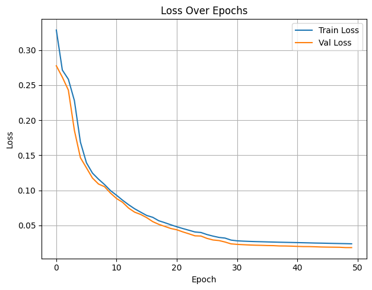

```python
import matplotlib.pyplot as plt

def plot_training_history(history):
    # Loss
    plt.figure(figsize=(12, 5))

    # Plot Loss
    plt.subplot(1, 2, 1)
    plt.plot(history.history['loss'], label='Train Loss')
    plt.plot(history.history['val_loss'], label='Val Loss')
    plt.title('Loss Over Epochs')
    plt.xlabel('Epoch')
    plt.ylabel('Loss')
    plt.legend()
    plt.grid(True)

    # Plot Accuracy if available
    if 'accuracy' in history.history:
        plt.subplot(1, 2, 2)
        plt.plot(history.history['accuracy'], label='Train Accuracy')
        plt.plot(history.history['val_accuracy'], label='Val Accuracy')
        plt.title('Accuracy Over Epochs')
        plt.xlabel('Epoch')
        plt.ylabel('Accuracy')
        plt.legend()
        plt.grid(True)

    plt.tight_layout()
    plt.show()

plot_training_history(results)
```

Run the next section as is as well. You should understand what this section is doing

```python
# # The paths below should work for your images and masks if you downloaded and uploaded the folders to your drive
test_image_dir = '/content/drive/MyDrive/test_images-20250615T225233Z-1-001/test_images'
test_mask_dir = '/content/drive/MyDrive/test_masks-20250615T225256Z-1-001/test_masks'

# Load and preprocess images and masks
test_images, test_masks = load_and_preprocess_images(test_image_dir, test_mask_dir)

# Check shape of loaded images and masks
print(test_images.shape, test_masks.shape)
test_images = np.array(test_images) / 255.0
test_masks = (test_masks > 127).astype(np.float32)
```

```
Found 20 matched image-mask pairs.
Generated 800 image-mask pairs.
(800, 256, 256, 3) (800, 256, 256, 1)
```

```
1/1 ━━━━━━━━━━━━━━━━━━━━ 2s 2s/step
```

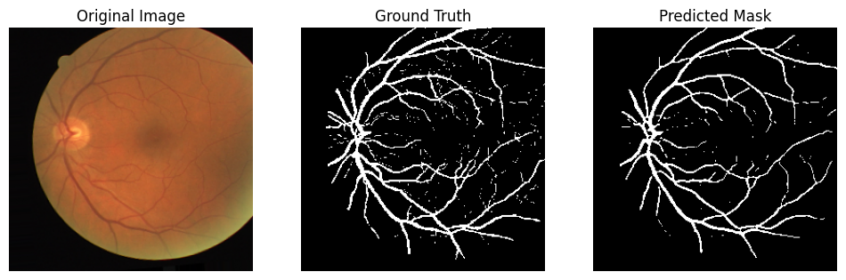

```python
import matplotlib.pyplot as plt

def visualize_prediction(image, mask, pred_mask):
    plt.figure(figsize=(12, 4))

    plt.subplot(1, 3, 1)
    plt.title('Original Image')
    plt.imshow(image.squeeze(), cmap='gray')
    plt.axis('off')

    plt.subplot(1, 3, 2)
    plt.title('Ground Truth')
    plt.imshow(mask.squeeze(), cmap='gray')
    plt.axis('off')

    plt.subplot(1, 3, 3)
    plt.title('Predicted Mask')
    plt.imshow(pred_mask.squeeze(), cmap='gray')
    plt.axis('off')

    plt.show()

# Example usage:
i = 0
sample_image = test_images[i:i+1]
prediction = model.predict(sample_image)[0]
prediction = (prediction > 0.5).astype(np.uint8)
visualize_prediction(test_images[i], test_masks[i], prediction)
```